# Week 9 seminar (complete)

Author

Joshua Loftus

```r
library(tidyverse)      # should've already install.packages("tidyverse")
library(randomForest)   # might need to install.packages("randomForest")
library(kernelshap)     # Shapley values; might need to install.packages("kernelshap")
library(mgcv)           # ships with R
library(NHANES)         # the optional item's data; might need to install.packages("NHANES")
library(xgboost)        # the optional item; version 3 or later
library(patchwork)      # two plots side by side
theme_set(theme_minimal())
options(pillar.sigfig = 4)   # tables print four significant digits
mse <- function(y, pred) mean((y - pred)^2)
pct <- function(v) sprintf("%.0f%%", 100 * v)
```

## Before the seminar

The lecture stated two results without proof: exercise 1 proves quantile optimality, and exercise 2 proves the coverage of a split conformal interval. Exercise 3 computes partial dependence and individual curves by hand. Do all three on paper before the seminar. You may use, without proof: differentiation under the integral sign (if $G(a) = \int_{-\infty}^a h(y, a)\,dy$, then $G'(a) = h(a, a) + \int_{-\infty}^a \partial_a h(y, a)\,dy$, and similarly for $\int_a^\infty$, where the boundary term changes sign); and that if $V_1, \ldots, V_{m+1}$ are independent draws from one continuous distribution, every ordering of them is equally likely.

**WarningHints**

Each exercise has hints, collapsed below it. Do not open a hint unless you have been stuck for at least a few minutes, and open them in order. Solutions are shown in the seminar if you ask.

**Exercise 1 (quantile optimality).** $Y$ has a continuous distribution function $F$ with a density $f$ and a finite mean, and $0 < \tau < 1$. The pinball loss of a prediction $\hat y$ is $\rho_\tau(y - \hat y) = (y - \hat y)\big(\tau - \mathbf 1\{y < \hat y\}\big)$. Let $G(\hat y) = \mathbb E[\rho_\tau(Y - \hat y)]$.

1. Before any calculus: move the prediction from $\hat y$ up to $\hat y + \delta$, with $\delta > 0$ small. How does the loss change for an outcome below $\hat y$? For an outcome above $\hat y + \delta$? Use this to guess at which $\hat y$ the expected loss stops falling.
2. Write $G(\hat y)$ as two integrals, one over $y < \hat y$ and one over $y \ge \hat y$, and show that $G'(\hat y) = F(\hat y) - \tau$.
3. Show that $G$ is convex, and conclude that a $\tau$-quantile, a value $q_\tau$ with $F(q_\tau) = \tau$, minimizes $G$. When is the minimizer not unique?
4. Suppose that, for each $x$, $Y$ given $X = x$ has a continuous distribution function with a density and a finite mean. Explain why the same argument shows that the conditional $\tau$-quantile $q_\tau(x)$ is the best prediction at $x$, and why the function $x \mapsto q_\tau(x)$ minimizes $\mathbb E[\rho_\tau(Y - h(X))]$ over functions $h$.

**NoteHint 1**

1. Below the prediction the loss is $(1 - \tau)(\hat y - y)$; above it, $\tau(y - \hat y)$. Which outcomes are below $\hat y$, and with what probability?

**NoteHint 2**

2. The boundary terms from differentiating under the integral sign are zero: at $y = \hat y$ both integrands vanish.

**NoteHint 3**

3. A differentiable function whose derivative is nondecreasing is convex. (d) $\mathbb E[\rho_\tau(Y - h(X))] = \mathbb E\big[\mathbb E[\rho_\tau(Y - h(X)) \mid X]\big]$.

**TipReveal solution**

1. For an outcome below $\hat y$ the loss is $(1 - \tau)(\hat y - y)$, so moving the prediction up by $\delta$ adds $(1 - \tau)\delta$; such outcomes have probability $F(\hat y)$. For an outcome above $\hat y + \delta$ the loss is $\tau(y - \hat y)$, which falls by $\tau\delta$; probability about $1 - F(\hat y)$. Outcomes between $\hat y$ and $\hat y + \delta$ have probability about $f(\hat y)\delta$ and change by at most $\delta$, a second-order term. So the expected loss changes by about
   $$\delta\big[(1 - \tau)F(\hat y) - \tau\big(1 - F(\hat y)\big)\big] = \delta\big(F(\hat y) - \tau\big),$$
   negative while $F(\hat y) < \tau$ and positive once $F(\hat y) > \tau$. Guess: the expected loss is smallest where $F(\hat y) = \tau$.
2. Splitting at $\hat y$,
   $$G(\hat y) = (1 - \tau)\int_{-\infty}^{\hat y}(\hat y - y) f(y)\,dy + \tau\int_{\hat y}^\infty (y - \hat y) f(y)\,dy,$$
   both finite because $\mathbb E|Y| < \infty$. Differentiating under the integral sign, the boundary terms are $(\hat y - \hat y)f(\hat y) = 0$, and
   $$G'(\hat y) = (1 - \tau)\int_{-\infty}^{\hat y} f(y)\,dy - \tau\int_{\hat y}^\infty f(y)\,dy = (1 - \tau)F(\hat y) - \tau\big(1 - F(\hat y)\big) = F(\hat y) - \tau.$$
3. $G'(\hat y) = F(\hat y) - \tau$ is nondecreasing in $\hat y$, so $G$ is convex. $F$ is continuous and goes from 0 to 1, so some $q_\tau$ has $F(q_\tau) = \tau$; there $G' = 0$, and a point where the derivative of a convex function is zero is a minimum. $G' < 0$ below every such point and $G' > 0$ above, so the set of minimizers is the set of $\hat y$ with $F(\hat y) = \tau$. It has more than one point when $F$ is flat at height $\tau$, which happens when $Y$ puts no probability on an interval between two parts of its distribution. $\blacksquare$
4. Given $X = x$, $Y$ has the conditional distribution function $F(\cdot \mid x)$, which by assumption is continuous with a density and a finite mean, so (a) to (c) apply to it unchanged: the best prediction at $x$ is $q_\tau(x)$. For any function $h$, $\mathbb E[\rho_\tau(Y - h(X))] = \mathbb E\big[\mathbb E[\rho_\tau(Y - h(X)) \mid X]\big]$, and the inner expectation at $X = x$ is smallest when $h(x) = q_\tau(x)$. Choosing $q_\tau(x)$ at every $x$ makes every inner expectation as small as it can be, so it minimizes the average too: the same argument as for the mean (squared loss) and the threshold (0–1 loss with costs).

Common errors: dropping the minus sign in front of the second integral’s derivative; getting $F(\hat y) = 1 - \tau$ by giving weight $\tau$ to the wrong side; assuming the quantile is always unique.

**Exercise 2 (coverage of a split conformal interval; Lei et al. 2018).** A model $\hat f$ has been fitted on training rows. Then $m$ held-out rows $(X_1, Y_1), \ldots, (X_m, Y_m)$ and a new row $(X, Y)$ are independent draws from one distribution, independent of the training rows. Write $R_i = |Y_i - \hat f(X_i)|$ and $R = |Y - \hat f(X)|$, and assume these have a continuous distribution, so that there are no ties. Let $k = \lceil 0.9(m + 1)\rceil$, assume $k \le m$, and let $C$ be the $k$th smallest of $R_1, \ldots, R_m$. The interval is $\hat f(X) \pm C$.

1. Explain why, given the training rows, $R_1, \ldots, R_m, R$ are independent and identically distributed. Show that the interval covers $Y$ exactly when $R$ is among the $k$ smallest of all $m + 1$ values, and conclude that $P\big(Y \in \hat f(X) \pm C\big) = k/(m + 1) \ge 0.9$. What does this probability average over?
2. Compute $k$ and the coverage for $m = 9$, $19$ and $1{,}000$. What happens when $m = 5$?
3. Suppose $C$ is computed the same way from the training rows’ residuals instead. Which step of (a) fails, and in which direction does the coverage usually move?
4. Suppose the held-out rows were also used to choose between several models before $C$ was computed. Which step of (a) fails?

**NoteHint 1**

1. Given the training rows, $\hat f$ is a fixed function.

**NoteHint 2**

1. The interval covers $Y$ when $R \le C$. If $R \le C$, how many of $R_1, \ldots, R_m$ can be smaller than $R$?

**TipReveal solution**

1. Given the training rows, $\hat f$ is a fixed function. The $m + 1$ rows $(X_1, Y_1), \ldots, (X_m, Y_m), (X, Y)$ are independent draws from one distribution and independent of $\hat f$, so $R_1, \ldots, R_m, R$, the same fixed function applied to each row, are independent and identically distributed.

The interval covers $Y$ exactly when $R \le C$. With no ties, $R < C$ means that the held-out values below $R$ are among the $k - 1$ that are below $C$, so at most $k - 1$ of them are below $R$ and $R$’s rank among all $m + 1$ values is at most $k$. Conversely, if $R$’s rank is at most $k$, at most $k - 1$ held-out values are below $R$, so the $k$th smallest held-out value is above it: $R < C$. Every ordering of the $m + 1$ values is equally likely, so $R$’s rank is equally likely to be each of $1, \ldots, m + 1$, and
$$P\big(Y \in \hat f(X) \pm C\big) = \frac{k}{m + 1} \ge \frac{0.9(m + 1)}{m + 1} = 0.9 .$$
Since $k < 0.9(m + 1) + 1$, the coverage is also below $0.9 + 1/(m + 1)$. The probability averages over the held-out rows and the new row, and so over $X$: it is marginal coverage, not coverage at each $x$. Given the training rows it holds for every set of training rows, so it holds on average over them too.

2. $m = 9$: $k = \lceil 9 \rceil = 9$, so $C$ is the largest held-out residual and the coverage is $9/10 = 0.9$. $m = 19$: $k = \lceil 18 \rceil = 18$, coverage $18/20 = 0.9$. $m = 1{,}000$: $k = \lceil 900.9\rceil = 901$, coverage $901/1001 = 0.9001$. $m = 5$: $k = \lceil 5.4 \rceil = 6 > 5$: even the largest of five held-out residuals is exceeded by $R$ with probability $1/6$, so no finite $C$ from these rows has the guarantee.
3. The first step: the training rows’ residuals are not independent of $\hat f$, so they are not exchangeable with $R$, and $R$’s rank among them need not be uniform. The argument then says nothing about the coverage, neither its direction nor its size. In practice it is usually below 0.9, because $\hat f$ was fitted to make the training residuals small, so a new residual tends to rank high among them; far below for a flexible model. A one-nearest-neighbor fit has every training residual equal to zero, so $C = 0$ and the interval covers nothing.
4. The step “given the training rows, $\hat f$ is fixed and independent of the held-out rows”. The chosen model depends on the held-out rows, so their residuals are no longer exchangeable with the new row’s: the uniform rank, and with it the guarantee, is lost. The argument does not say how much the coverage moves; choosing the model that fits the held-out rows best tends to make their residuals a little smaller, and with a handful of candidates the loss is usually small.

Common errors: $k = \lceil 0.9m \rceil$, which can fall short (for $m = 10$ it gives $k = 9$ and coverage $9/11 = 0.82$); reading the 90% as holding at each $x$; forgetting that it averages over the held-out rows, so one set of held-out rows can give an interval that covers somewhat more or less.

**Exercise 3 (partial dependence by hand).** A fitted model is $\hat f(x_1, x_2) = x_1x_2$, and the data are four units:

| Unit | $x_1$ | $x_2$ |
| --- | --- | --- |
| 1 | 0 | $-2$ |
| 2 | 1 | $-1$ |
| 3 | 2 | 1 |
| 4 | 3 | 2 |

The individual conditional expectation (ICE) curve of unit $i$ for $x_1$ is $t \mapsto \hat f(t, x_{i2})$, and the partial dependence plot (PDP) for $x_1$ is their average, $\mathrm{PDP}_1(t) = \frac14\sum_{i=1}^4 \hat f(t, x_{i2})$.

1. Evaluate each unit’s ICE curve for $x_1$ at $t = -1, 0, 1$, and sketch the four curves.
2. Compute $\mathrm{PDP}_1(t)$. Does the PDP say that $\hat f$ uses $x_1$? Does it?
3. Compute the PDP for $x_2$. The model treats $x_1$ and $x_2$ alike; why are the two PDPs different?
4. Now $\hat f(x_1, x_2) = g_1(x_1) + g_2(x_2)$ for any functions $g_1$ and $g_2$. Show that the ICE curves for $x_1$ are parallel and that $\mathrm{PDP}_1(t) = g_1(t) + c$ for a constant $c$.
5. Unit 1’s ICE curve at $t = 3$ evaluates $\hat f(3, -2)$. Is there a unit like that in the data?

**NoteHint 1**

(a), (b) Each ICE curve is a line through the origin. In the sum for $\mathrm{PDP}_1(t)$, $t$ is the same for every unit.

**TipReveal solution**

1. Unit $i$’s ICE curve is $t \mapsto t\,x_{i2}$, a line through the origin with slope $x_{i2}$:

| $t$ | Unit 1 | Unit 2 | Unit 3 | Unit 4 | Average |
| --- | --- | --- | --- | --- | --- |
| $-1$ | 2 | 1 | $-1$ | $-2$ | 0 |
| 0 | 0 | 0 | 0 | 0 | 0 |
| 1 | $-2$ | $-1$ | 1 | 2 | 0 |

2. $\mathrm{PDP}_1(t) = \frac14\sum_i t\,x_{i2} = t \times \frac14(-2 - 1 + 1 + 2) = 0$ for every $t$. The PDP is flat, which looks like “the model does not use $x_1$”. It does: every ICE curve has slope $x_{i2} \ne 0$, and the slopes cancel in the average. A PDP averages away an interaction like this one.
3. $\mathrm{PDP}_2(t) = \frac14\sum_i x_{i1}\,t = 1.5\,t$, since the $x_1$ values average $1.5$. The model is symmetric in its inputs, but the PDP for one input averages over the other input’s values, and these average 0 for $x_2$ and 1.5 for $x_1$.
4. Unit $i$’s ICE curve is $g_1(t) + g_2(x_{i2})$: the curve $g_1$ shifted by a constant that depends on the unit, so the curves are parallel. Their average is $g_1(t) + c$ with $c = \frac14\sum_i g_2(x_{i2})$. For an additive model the PDP is the component curve up to a constant, and the ICE curves add nothing.
5. No. In these units $x_1$ and $x_2$ rise together, and the unit with $x_2 = -2$ has $x_1 = 0$. The ICE curve, and so the PDP, evaluates $\hat f$ at combinations of inputs that may be unlike any unit in the data, where the model was never fitted.

Common errors: averaging over $t$ instead of over units; reading the flat PDP in (b) as “$x_1$ does not matter”.

## Problems

Problems 1 and 2 use the normal distribution function $\Phi$; for a 90% interval, $\Phi(1.645) = 0.95$. If $W \sim N(\mu, s^2)$, then $P(|W| \le c) = \Phi\big((c - \mu)/s\big) - \Phi\big((-c - \mu)/s\big)$.

**Problem 1 (the residuals of a nearest-neighbor fit).** The inputs come in groups of $k$ rows that share the same $x$, and $Y = f^\star(x) + \varepsilon$ with $\varepsilon \sim N(0, \sigma^2)$, independent across rows. The $k$-nearest-neighbor fit predicts, at the $x$ of a group, the mean $\bar y$ of that group’s $k$ outcomes $y_1, \ldots, y_k$. A training row’s residual is $y_i - \bar y$. A new outcome at that $x$ is $Y_0 = f^\star(x) + \varepsilon_0$, independent of the group’s outcomes.

1. Find the distribution of a training residual $y_i - \bar y$, and of the new residual $Y_0 - \bar y$.
2. There are many groups, and $C$ is the 90th percentile of the absolute training residuals over all of them, so $C$ is close to the 90th percentile of the distribution of $|y_i - \bar y|$. Find it. Find the coverage $P(|Y_0 - \bar y| \le C)$ as a function of $k$, and evaluate it at $k = 1, 2, 5, 10$ and $50$.
3. Instead, $C$ comes from held-out rows: one more row in each group, not used in the fit. What is $C$ now, and the coverage? How much wider is the interval than $f^\star(x) \pm 1.645\sigma$, which needs the truth?
4. In this setting, larger $k$ gives a narrower interval with the right coverage. What does the setting leave out that stops us from taking $k$ as large as we like?

**NoteHint 1**

1. $\bar y$ contains $\varepsilon_i$ itself, but not $\varepsilon_0$.

**NoteHint 2**

2. If $W \sim N(0, s^2)$, the 90th percentile of $|W|$ is $1.645s$.

**TipReveal answer**

1. $y_i - \bar y = \varepsilon_i - \bar\varepsilon = \big(1 - \frac1k\big)\varepsilon_i - \frac1k\sum_{j \ne i}\varepsilon_j$, a sum of independent normals with mean 0 and variance
   $$\sigma^2\Big[\Big(1 - \frac1k\Big)^2 + \frac{k - 1}{k^2}\Big] = \sigma^2\Big(1 - \frac1k\Big).$$
   $Y_0 - \bar y = \varepsilon_0 - \bar\varepsilon$, and $\varepsilon_0$ is independent of $\bar\varepsilon$, so the variances add: $N\big(0, \sigma^2(1 + \frac1k)\big)$. The fit was pulled toward each training outcome, so the training residuals are smaller than a new one.
2. $C = 1.645\sigma\sqrt{1 - 1/k}$. Then
   $$P(|Y_0 - \bar y| \le C) = P\Big(|Z| \le 1.645\sqrt{\tfrac{k - 1}{k + 1}}\Big) = 2\Phi\Big(1.645\sqrt{\tfrac{k - 1}{k + 1}}\Big) - 1, \qquad Z \sim N(0, 1).$$

| $k$ | 1 | 2 | 5 | 10 | 50 |
| --- | --- | --- | --- | --- | --- |
| Coverage | 0 | 66% | 82% | 86% | 89% |

With $k = 1$ every training residual is 0, so $C = 0$: a model that fits its training data perfectly reports no uncertainty at all.

3. A held-out row’s residual has the new residual’s distribution, so $C = 1.645\sigma\sqrt{1 + 1/k}$ and the coverage is 90% for every $k$. The interval is $\sqrt{1 + 1/k}$ times as wide as $f^\star(x) \pm 1.645\sigma$: 1.41, 1.22, 1.10, 1.05 and 1.01 for the same $k$. The extra width is the fit’s own variance.
4. Here $f^\star$ is the same for all $k$ neighbors. In general, the $k$ nearest rows lie farther from $x$ as $k$ grows, where $f^\star$ is different, so $\bar y$ is biased; problem 2 studies that.

Common errors: giving the training residual variance $\sigma^2/k$, the variance of $\bar y$; adding $\varepsilon_i$’s variance twice; reading $k = 1$ as a perfect interval.

**Problem 2 (smoothing bias and the confidence interval).** One input. The rows are spread evenly in $x$, $n$ of them per unit of $x$, and $Y = f^\star(x) + \varepsilon$ with independent $N(0, \sigma^2)$ errors, $\sigma$ known. At a point $x_0$ the fit $\hat f(x_0)$ averages the $k = 2nh$ outcomes with $|x_i - x_0| \le h$. $f^\star$ is twice differentiable, with $f^{\star\prime\prime}(x_0) = a \ne 0$. For small $h$, use $f^\star(x_i) \approx f^\star(x_0) + f^{\star\prime}(x_0)(x_i - x_0) + \frac a2(x_i - x_0)^2$, and treat the $x_i$ in the window as spread evenly over it, so that the average of $x_i - x_0$ is 0 and the average of $(x_i - x_0)^2$ is $h^2/3$.

1. Show that the bias $\mathbb E\hat f(x_0) - f^\star(x_0)$ is about $ah^2/6$, and that the variance of $\hat f(x_0)$ is $\sigma^2/(2nh)$.
2. Find the $h$ that minimizes the mean squared error, bias$^2$ + variance, and show that, to the order of these approximations, at that $h$ the size of the bias is half the standard deviation of $\hat f(x_0)$, $|\text{bias}|/\mathrm{sd} = 1/2$, whatever $n$, $\sigma$ and $a$.
3. The confidence interval $\hat f(x_0) \pm 1.645\,\mathrm{sd}$ for $f^\star(x_0)$, with $\mathrm{sd} = \sigma/\sqrt k$, ignores the bias. What is its coverage at the $h$ of (b)? Does more data help?
4. With $d$ inputs and a window of half-width $h$ in each, the bias is still proportional to $h^2$ and the variance to $1/(nh^d)$. Show that at the $h$ that minimizes the mean squared error, $|\text{bias}|/\mathrm{sd} = \sqrt d/2$, and find the coverage for $d = 4$ and $d = 9$.
5. The prediction interval $\hat f(x_0) \pm 1.645\sqrt{\sigma^2 + \mathrm{sd}^2}$ for a new outcome $Y_0 = f^\star(x_0) + \varepsilon_0$. With one input, the $h$ of (b) and $k = 90$, what is its coverage?
6. How would you change the fit used for the confidence interval to bring its coverage back to 90%, and what does that cost?

**NoteHint 1**

1. Average the expansion of $f^\star(x_i)$ over the window: the linear term averages to zero.

**NoteHint 2**

2. Set the derivative of the mean squared error in $h$ to zero, and compare the two terms at that $h$ without solving for it.

**NoteHint 3**

3. $(\hat f(x_0) - f^\star(x_0))/\mathrm{sd}$ is normal, with mean bias/sd and variance 1.

**TipReveal answer**

1. $\mathbb E\hat f(x_0) = \frac1k\sum_{|x_i - x_0| \le h} f^\star(x_i)$. Averaging the expansion over the window, the constant stays, the linear term averages to 0 and the quadratic term to $\frac a2 \cdot \frac{h^2}{3}$, so the bias is about $ah^2/6$. The variance of a mean of $k$ independent errors is $\sigma^2/k = \sigma^2/(2nh)$.
2. The mean squared error is $M(h) = \frac{a^2h^4}{36} + \frac{\sigma^2}{2nh}$, with
   $$M'(h) = \frac{4}{h}\cdot\frac{a^2h^4}{36} - \frac1h\cdot\frac{\sigma^2}{2nh} = \frac1h\big(4\,\text{bias}^2 - \text{variance}\big).$$
   At the minimizing $h$, $h^5 = 9\sigma^2/(2na^2)$, we have $4\,\text{bias}^2 = \text{variance}$, so $|\text{bias}|/\mathrm{sd} = 1/2$, whatever $n$, $\sigma$ and $a$.
3. $(\hat f(x_0) - f^\star(x_0))/\mathrm{sd} \sim N(\pm\frac12, 1)$, so the coverage is $\Phi(1.645 - 0.5) - \Phi(-1.645 - 0.5) = 0.874 - 0.016 = 0.858$. The sign of the bias is that of $a$: negative at a peak, where $a < 0$. More data does not help: the best $h$ shrinks as $n$ grows, but the ratio stays $1/2$, so to leading order the interval covers 86% at every $n$. These are approximations for small $h$; at a given $n$ the coverage is near 86%, not exactly 86%.
4. With bias $= Bh^2$ and variance $= V/(nh^d)$, $M'(h) = \frac1h\big(4\,\text{bias}^2 - d\,\text{variance}\big)$, so at the minimum $|\text{bias}|/\mathrm{sd} = \sqrt d/2$. For $d = 4$ the shift is 1 and the coverage $\Phi(0.645) - \Phi(-2.645) = 0.74$; for $d = 9$ it is 1.5 and the coverage $\Phi(0.145) - \Phi(-3.145) = 0.56$. The more inputs, the more the fit that predicts best trades variance for bias, and the worse its confidence interval.
5. $Y_0 - \hat f(x_0) \sim N\big(-\text{bias}, \sigma^2 + \mathrm{sd}^2\big)$. With $k = 90$, $\mathrm{sd} = \sigma/\sqrt{90} = 0.105\sigma$ and the bias is $0.053\sigma$, so the shift in units of the interval’s scale is $0.053/\sqrt{1 + 1/90} = 0.052$, and the coverage is 89.95%. The prediction interval compares the bias with $\sigma$, not with sd, so a bias that ruins the confidence interval hardly moves it.
6. Use a smaller $h$ for the interval than for the prediction (undersmoothing): $|\text{bias}|/\mathrm{sd}$ shrinks toward 0 as $h$ shrinks faster than the MSE-best rate, and the coverage returns toward 90%, but sd is larger, so the interval is wider. Or estimate the bias (it needs an estimate of $a$) and subtract it, which adds variance of its own.

Common errors: averaging the linear term to something nonzero; solving for $h$ and then losing track of the ratio, which is easier to read from $M'(h) = 0$; concluding that a bias of half a standard deviation is harmless because it is small in absolute terms.

**Problem 3 (calibration in two groups).** A score takes the values 0.2 and 0.8. In two groups of 100 people:

| Group | Score | People | With the condition |
| --- | --- | --- | --- |
| A | 0.8 | 50 | 40 |
| A | 0.2 | 50 | 10 |
| B | 0.8 | 20 | 16 |
| B | 0.2 | 80 | 16 |

1. Find each group’s base rate. Is the score calibrated within each group? Overall?
2. Predict 1 when the score is above 0.5. In each group, find the true positive rate (the share of people with the condition who are predicted 1), the false positive rate (the share of people without it who are predicted 1) and the positive predictive value (the share of people predicted 1 who have it).
3. In each group, find the average score among people with the condition and among people without it.
4. Let $S$ be any score that is calibrated in a group with base rate $p$, so $P(Y = 1 \mid S) = S$. Show that $\mathbb E S = p$, and so $p\,\mathbb E[S \mid Y = 1] + (1 - p)\,\mathbb E[S \mid Y = 0] = p$. Use this to show that two groups with different base rates cannot have the same $\mathbb E[S \mid Y = 1]$ and the same $\mathbb E[S \mid Y = 0]$, unless $\mathbb E[S \mid Y = 1] = 1$ and $\mathbb E[S \mid Y = 0] = 0$.

**NoteHint 1**

4. $\mathbb E S = \mathbb E\big[P(Y = 1 \mid S)\big]$. Write the second equation for both groups with the same two averages, and divide one by the other.

**TipReveal answer**

1. Group A: $50/100 = 0.50$. Group B: $32/100 = 0.32$. In A, $40/50 = 0.8$ of the people with score 0.8 have the condition and $10/50 = 0.2$ of those with 0.2; in B, $16/20 = 0.8$ and $16/80 = 0.2$. Overall, $56/70 = 0.8$ and $26/130 = 0.2$. Calibrated within each group and overall.
2. Group A: 40 of the 50 people with the condition are predicted 1, TPR 0.8; 10 of the 50 without, FPR 0.2; 40 of the 50 predicted 1 have it, PPV 0.8. Group B: 16 of 32, TPR 0.5; 4 of 68, FPR 0.059; 16 of 20, PPV 0.8. The same positive predictive value, and different error rates: people with the condition in group B are missed half the time, in group A one time in five. When base rates differ, a rule whose positive predictive value is the same in both groups, and strictly between 0 and 1, cannot also have equal false positive and false negative rates (Chouldechova 2017). The condition matters: a rule with no false positives has PPV 1, and can miss half the people with the condition in both groups.
3. A, with the condition: $(40 \times 0.8 + 10 \times 0.2)/50 = 0.68$; without: $(10 \times 0.8 + 40 \times 0.2)/50 = 0.32$. B, with: $(16 \times 0.8 + 16 \times 0.2)/32 = 0.50$; without: $(4 \times 0.8 + 64 \times 0.2)/68 = 0.235$.
4. $\mathbb E S = \mathbb E\big[P(Y = 1 \mid S)\big] = P(Y = 1) = p$, and splitting $\mathbb E S$ by $Y$ gives $p\,\mathbb E[S \mid Y = 1] + (1 - p)\,\mathbb E[S \mid Y = 0] = p$; (c)’s numbers satisfy it ($0.5 \times 0.68 + 0.5 \times 0.32 = 0.5$ and $0.32 \times 0.5 + 0.68 \times 0.235 = 0.32$). Suppose both groups have the same $s_1 = \mathbb E[S \mid Y = 1]$ and $s_0 = \mathbb E[S \mid Y = 0]$. Rearranging, $(1 - p)s_0 = p(1 - s_1)$ in each group. If $s_1 < 1$, dividing gives $\frac{s_0}{1 - s_1} = \frac{p}{1 - p}$, and $\frac{p}{1 - p}$ is increasing in $p$, so the two base rates would be equal. So with different base rates $s_1 = 1$, and then $(1 - p)s_0 = 0$ gives $s_0 = 0$: the score is 1 for everyone with the condition and 0 for everyone without. This is one of the conflicts between fairness criteria shown by Kleinberg, Mullainathan and Raghavan (2017).

Common errors: dividing false positives by everyone in the group rather than by the people without the condition; reading equal positive predictive value as equal treatment.

## Coding

Two simulations, where the truth is known: part 1 checks intervals at one point, and part 2 asks a fitted model a causal question. The optional item at the end recalibrates a score on the NHANES adults, with the lecture’s split, which is made here so that the seed is set once, before every random step below.

```r
nh <- NHANESraw |>
  filter(Age >= 20) |>
  select(Diabetes, Gender, Age, Race1, Poverty, Weight, Height, BMI, Pulse, BPSysAve, TotChol, DirectChol, PhysActive) |>
  drop_na() |>
  mutate(diabetes = as.numeric(Diabetes == "Yes"), male = as.numeric(Gender == "male"),
         active = as.numeric(PhysActive == "Yes"))
set.seed(310)   # change this number: a different split, and different numbers below
nh_id <- sample(nrow(nh))
nh_train <- nh[nh_id[1:4000], ]
nh_tune <- nh[nh_id[4001:7000], ]
nh_test <- nh[nh_id[7001:nrow(nh)], ]
```

### 1. Intervals at one point

One input, uniform on $[0, 1]$; $f^\star(x) = \sin(2\pi x)$; noise $N(0, 1)$; 500 training rows. At $x_0 = 0.25$, $f^\star$ is at its peak, $f^\star(x_0) = 1$. The $k$-nearest-neighbor fit at $x_0$ averages the outcomes of the $k$ rows whose $x$ is closest to $x_0$. With $\sigma = 1$ known, the usual intervals, which ignore any bias, are: for $f^\star(x_0)$, the confidence interval $\hat f(x_0) \pm 1.645/\sqrt k$; for a new outcome $Y_0$ at $x_0$, the prediction interval $\hat f(x_0) \pm 1.645\sqrt{1 + 1/k}$.

```r
f_star <- function(x) sin(2 * pi * x)
sim <- function(n) tibble(x = runif(n), y = f_star(x) + rnorm(n))
x0 <- 0.25
ks <- c(5, 10, 25, 50, 90, 150, 250)
```

**Question 1.** Complete `knn_at(x0, k, d)`, which returns the mean outcome of the `k` rows of `d` whose `x` is closest to `x0`. On one sample of 500 rows, compute the fit at $x_0$ for each `k` in `ks`. Then look at the plot of the fits for $k = 10$ and $k = 150$ across $x$. What goes wrong for small $k$, and for large $k$?

```r
# knn_at <- function(x0, k, d) ____
d <- sim(500)
# round(sapply(ks, function(k) knn_at(x0, k, d)), 3)
```

**TipReveal solution**

```r
knn_at <- function(x0, k, d) mean(d$y[order(abs(d$x - x0))[1:k]])
d <- sim(500)
q1 <- sapply(ks, function(k) knn_at(x0, k, d))
round(setNames(q1, ks), 3)
```

```
    5    10    25    50    90   150   250
0.216 0.500 0.727 0.833 0.846 0.635 0.565
```

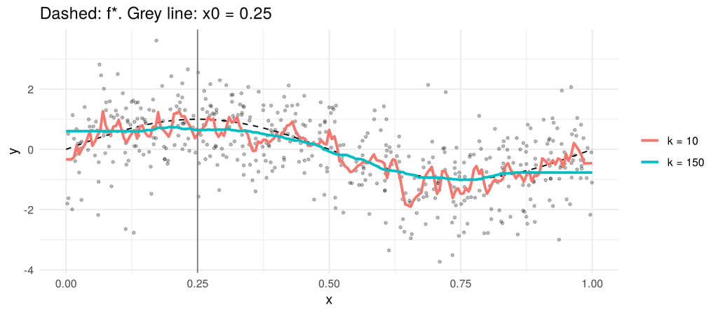

```r
x_grid <- seq(0, 1, by = 0.005)
curves <- expand_grid(k = c(10, 150), x = x_grid) |>
  mutate(fit = map2_dbl(x, k, function(x, k) knn_at(x, k, d)), k = paste("k =", k))
ggplot(d, aes(x, y)) + geom_point(alpha = 0.25, size = 0.8) +
  geom_line(data = tibble(x = x_grid, y = f_star(x_grid)), linetype = "dashed") +
  geom_line(data = curves, aes(x, fit, colour = k), linewidth = 1) +
  geom_vline(xintercept = x0, colour = "grey50") +
  labs(colour = NULL, title = "Dashed: f*. Grey line: x0 = 0.25")
```

**TipReveal answer**

On this sample the fit at $x_0$ is 0.22, 0.50, 0.73, 0.83, 0.85, 0.63, 0.57 for $k$ = 5, 10, 25, 50, 90, 150, 250, against $f^\star(x_0) = 1$. With $k = 10$ the curve follows the noise of a few rows (variance). With $k = 150$ the neighbors of $x_0$ reach about 0.15 on each side, where $\sin(2\pi x)$ is well below its peak, so the average is pulled down at the peak and up at the trough (bias). One sample cannot separate the two; question 2 repeats the experiment.

Common errors: `order(d$x - x0)`, without the absolute value, which takes the rows with the smallest $x$; `sort()` in place of `order()`, which returns the distances instead of the rows.

**Question 2.** Repeat on 2,000 samples of 500 rows (the chunk below, about 3 seconds). For each `k`, estimate the bias and the standard deviation of $\hat f(x_0)$, its mean squared error, and how often each interval covers: the confidence interval covers $f^\star(x_0)$, and the prediction interval covers a new outcome $Y_0$. At which `k` is the mean squared error smallest? How often does each interval cover there?

```r
fits <- replicate(2000, { d_s <- sim(500); sapply(ks, function(k) knn_at(x0, k, d_s)) })   # one row per k, one column per sample
y0 <- f_star(x0) + rnorm(2000)                                                            # a new outcome for each sample
```

```r
# q2 <- tibble(k = ks,
#              bias = rowMeans(fits) - f_star(x0),
#              sd = apply(fits, 1, sd),
#              mse = ____,
#              ci_covers = ____,
#              pi_covers = ____)
# q2
```

**TipReveal solution**

```r
z <- qnorm(0.95)
q2 <- tibble(k = ks,
             bias = rowMeans(fits) - f_star(x0),
             sd = apply(fits, 1, sd),
             mse = rowMeans((fits - f_star(x0))^2),
             ci_covers = rowMeans(abs(fits - f_star(x0)) <= z / sqrt(ks)),
             pi_covers = rowMeans(abs(sweep(fits, 2, y0)) <= z * sqrt(1 + 1 / ks)))
q2
```

```
# A tibble: 7 x 6
      k      bias      sd     mse ci_covers pi_covers
  <dbl>     <dbl>   <dbl>   <dbl>     <dbl>     <dbl>
1     5 -0.006166 0.4524  0.2046     0.894     0.898
2    10 -0.001060 0.3124  0.09756    0.9055    0.8995
3    25 -0.01145  0.2049  0.04209    0.8905    0.896
4    50 -0.02331  0.1422  0.02076    0.892     0.8945
5    90 -0.05632  0.1040  0.01398    0.8495    0.8985
6   150 -0.1447   0.08392 0.02798    0.4535    0.894
7   250 -0.3660   0.07341 0.1393     0         0.879
```

```r
best <- q2 |> slice_min(mse)
```

Checkpoint (run it; if it stops, fix question 2 before going on): for small `k` the bias is negligible, so the confidence interval should cover about 90%.

```r
stopifnot(abs(q2$ci_covers[q2$k == 10] - 0.9) < 0.03)
```

**TipReveal answer**

The mean squared error is smallest at $k$ = 90 (0.014). There the bias is -0.056, 0.54 of a standard deviation, and the confidence interval covers 85% instead of 90%; problem 2 shows that a fit tuned to predict well has a bias of about half a standard deviation, and so a coverage of about 86%. At $k = 150$ the bias is 1.72 standard deviations and the confidence interval covers 45%; at $k = 250$, 0%. The prediction interval covers 88% to 90% at every $k$.

Common errors: comparing the fits with `y0` for the confidence interval, which asks about $f^\star(x_0)$; using `sd(fits)` over all $k$ at once.

**Question 3.** Using question 2’s table: which `k` would you use for a confidence interval for $f^\star(x_0)$ that covers about 90%, and what does it cost? Why does the prediction interval keep its coverage at $k = 150$?

**TipReveal answer**

A $k$ smaller than the one that predicts best: at $k$ = 25 the confidence interval covers 89%, with half-width $1.645/5 = 0.33$ against $1.645/\sqrt{90}$ = 0.17 at $k$ = 90. This is undersmoothing: the fit used for inference is rougher than the fit used for prediction. The prediction interval’s half-width is $1.645\sqrt{1 + 1/k}$, about 1.65, so a bias of 0.14 at $k = 150$ moves it only a little; the confidence interval’s half-width at $k = 150$ is 0.13, smaller than that bias.

**Question 4.** Now an interval at every $x$: $\hat f(x) \pm C$, with one $C$. For $k$ = 1, 5 and 25 and the sample `d` from question 1, compute $C$ two ways: as the 90th percentile of the absolute training residuals (each training row’s fit uses that row too), and from 500 held-out rows, as the $\lceil 0.9 \times 501 \rceil = 451$st smallest of their absolute residuals. Check each on 2,000 fresh rows. Compare with problem 1, which predicted 0%, 82% and 89% for training residuals when $f^\star$ is flat.

```r
hold <- sim(500)
fresh <- sim(2000)
# q4 <- map_dfr(c(1, 5, 25), function(k) {
#   fit_train <- sapply(d$x, function(x) knn_at(x, k, d))
#   pred_hold <- sapply(hold$x, function(x) knn_at(x, k, d))
#   pred_fresh <- sapply(fresh$x, function(x) knn_at(x, k, d))
#   C_train <- ____
#   C_hold <- ____
#   tibble(k, C_train, C_hold,
#          covers_train = mean(____),
#          covers_hold = mean(____))
# })
# q4
```

**TipReveal solution**

```r
hold <- sim(500)
fresh <- sim(2000)
q4 <- map_dfr(c(1, 5, 25), function(k) {
  fit_train <- sapply(d$x, function(x) knn_at(x, k, d))
  pred_hold <- sapply(hold$x, function(x) knn_at(x, k, d))
  pred_fresh <- sapply(fresh$x, function(x) knn_at(x, k, d))
  C_train <- quantile(abs(d$y - fit_train), 0.9)
  C_hold <- sort(abs(hold$y - pred_hold))[451]
  tibble(k, C_train, C_hold,
         covers_train = mean(abs(fresh$y - pred_fresh) <= C_train),
         covers_hold = mean(abs(fresh$y - pred_fresh) <= C_hold))
})
q4
```

```
# A tibble: 3 x 5
      k C_train C_hold covers_train covers_hold
  <dbl>   <dbl>  <dbl>        <dbl>       <dbl>
1     1   0      2.530       0            0.916
2     5   1.419  1.839       0.7925       0.893
3    25   1.566  1.699       0.873        0.897
```

**TipReveal answer**

With $C$ from the training residuals the interval covers 0%, 79%, 87% of fresh rows for $k$ = 1, 5 and 25; from held-out residuals, 92%, 89%, 90%. With $k = 1$ each training row is its own nearest neighbor, every training residual is 0, and the interval has width 0. With $k = 5$ and $25$ the training residuals are too small by about the factor $\sqrt{(k - 1)/(k + 1)}$ that problem 1 derived, and the coverage is close to its 82% and 89%, a little lower here because the neighborhoods overlap and $f^\star$ is not flat. The held-out $C$ is larger, 2.53, 1.84, 1.70 against 0.00, 1.42, 1.57, and gives about 90% for every $k$: on average over $x$, not at each $x$.

Common errors: `quantile(..., 0.9)` of the signed residuals instead of their absolute values; computing `pred_fresh` from `hold`.

### 2. Every tool, one causal question

A simulated world with three inputs. $x_1$ causes $x_2$; $x_1$ and $x_2$ cause $y$; $x_3$ is caused by $y$ and by $x_1$:
$$x_1 \sim \mathrm{Unif}[-2, 2], \quad x_2 = x_1 + \varepsilon_2, \quad y = \tfrac12 x_1 + \tfrac32\sin x_2 + \varepsilon_y, \quad x_3 = y + x_1 + \varepsilon_3,$$
with independent normal noises of standard deviations 0.8, 0.5 and 0.3. The question: **which input should we set, and how, to raise $y$, and by how much?** A forest fitted on all three inputs predicts $y$ well. Apply every interpretation tool from the lecture, write down what they suggest, then intervene in the simulator and compare.

```r
draw_world <- function(n) {
  x1 <- runif(n, -2, 2)
  x2 <- x1 + rnorm(n, 0, 0.8)
  y <- 0.5 * x1 + 1.5 * sin(x2) + rnorm(n, 0, 0.5)
  x3 <- y + x1 + rnorm(n, 0, 0.3)
  tibble(x1, x2, x3, y)
}
world <- draw_world(2000)
world_fresh <- draw_world(2000)
fit_all <- randomForest(y ~ x1 + x2 + x3, data = world, ntree = 300, mtry = 3, nodesize = 20)
```

**Question 5.** Compute the forest’s MSE on the fresh rows, and compare it with the variance of $y$.

```r
# base <- mse(world_fresh$y, ____)
# c(mse = base, var_y = var(world_fresh$y))
```

**TipReveal solution**

```r
base <- mse(world_fresh$y, predict(fit_all, world_fresh))
c(mse = base, var_y = var(world_fresh$y))
```

```
       mse      var_y
0.08099021 2.66334275
```

**TipReveal answer**

The fresh MSE is 0.081, against a variance of 2.66: the forest explains 97% of the variance of $y$. As a predictor it does very well.

**Question 6.** Importance, four ways. Split importance and Shapley values are computed in the chunk after this one. Write the other two: permutation importance (shuffle one input in the fresh rows and score again), and leave-one-covariate-out (LOCO: refit the forest without the input, with `mtry = 2` and the other settings unchanged, and score it on the fresh rows), each as the rise in fresh MSE over `base`. Which input does each measure rank first, and with what share of its total?

```r
# perm_imp <- sapply(c("x1", "x2", "x3"), function(j) {
#   d_perm <- world_fresh
#   d_perm[[j]] <- ____
#   ____ - base
# })
# fit_no_x1 <- randomForest(____, data = world, ntree = 300, mtry = 2, nodesize = 20)
# fit_no_x2 <- ____
# fit_no_x3 <- ____
# loco_imp <- c(x1 = ____, x2 = ____, x3 = ____)
```

**TipReveal solution**

```r
perm_imp <- sapply(c("x1", "x2", "x3"), function(j) {
  d_perm <- world_fresh
  d_perm[[j]] <- sample(d_perm[[j]])
  mse(world_fresh$y, predict(fit_all, d_perm)) - base
})
fit_no_x1 <- randomForest(y ~ x2 + x3, data = world, ntree = 300, mtry = 2, nodesize = 20)
fit_no_x2 <- randomForest(y ~ x1 + x3, data = world, ntree = 300, mtry = 2, nodesize = 20)
fit_no_x3 <- randomForest(y ~ x1 + x2, data = world, ntree = 300, mtry = 2, nodesize = 20)
loco_imp <- c(x1 = mse(world_fresh$y, predict(fit_no_x1, world_fresh)) - base,
              x2 = mse(world_fresh$y, predict(fit_no_x2, world_fresh)) - base,
              x3 = mse(world_fresh$y, predict(fit_no_x3, world_fresh)) - base)
```

```r
split_imp <- importance(fit_all)[, "IncNodePurity"]
shap <- permshap(fit_all, X = select(world_fresh[1:200, ], x1, x2, x3),
                 bg_X = select(world[1:200, ], x1, x2, x3), verbose = FALSE)   # about 5 seconds
shap_imp <- colMeans(abs(shap$S))
imp <- rbind(split = split_imp, permutation = perm_imp, LOCO = loco_imp, `mean |Shapley|` = shap_imp)
round(imp / rowSums(imp), 2)   # each measure as a share of its total
```

```
                 x1   x2   x3
split          0.02 0.03 0.95
permutation    0.03 0.02 0.95
LOCO           0.16 0.05 0.79
mean |Shapley| 0.12 0.09 0.79
```

**TipReveal answer**

Every measure ranks $x_3$ first, with shares of 0.95, 0.95, 0.79, 0.79 for split improvement, permutation, LOCO and mean absolute Shapley value. They disagree about $x_1$ and $x_2$, but not about which input the forest relies on: $x_3$ is $y$ plus $x_1$ plus a little noise, so given $x_1$ it nearly pins $y$ down.

Common errors: shuffling the training rows and scoring on the fresh ones, which mixes two changes; refitting with `mtry = 3` on two inputs, which `randomForest` resets with a warning.

**Question 7.** Partial dependence by hand. Complete `pdp_curve()`: for each value `t` in `grid`, set the input to `t` for every row of `d` and average the forest’s predictions. The chunk after it draws the three curves, and 100 of the 500 ICE curves for $x_1$. According to the PDP, what happens to $y$ when $x_1$ goes from $-1$ to $1$? What share of all 500 ICE curves for $x_1$ end lower at $1$ than at $-1$?

```r
# pdp_curve <- function(fit, d, input, grid) sapply(grid, function(t) {
#   d[[input]] <- ____
#   ____
# })
```

**TipReveal solution**

```r
pdp_curve <- function(fit, d, input, grid) sapply(grid, function(t) {
  d[[input]] <- t
  mean(predict(fit, d))
})
```

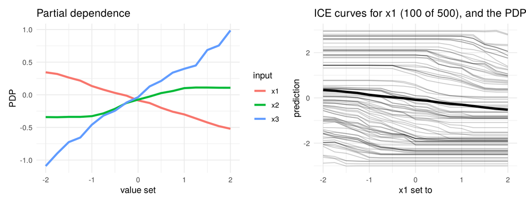

```r
grid <- seq(-2, 2, by = 0.25)
d_pd <- world_fresh[1:500, ]
pd <- tibble(t = grid, x1 = pdp_curve(fit_all, d_pd, "x1", grid), x2 = pdp_curve(fit_all, d_pd, "x2", grid),
             x3 = pdp_curve(fit_all, d_pd, "x3", grid))
ice <- d_pd[rep(1:100, each = length(grid)), ] |> mutate(unit = rep(1:100, each = length(grid)), t = rep(grid, 100), x1 = t)
ice$pred <- predict(fit_all, ice)                                                    # one ICE curve per unit, the first 100 units
slope_ice <- (predict(fit_all, mutate(d_pd, x1 = 1)) - predict(fit_all, mutate(d_pd, x1 = -1))) / 2   # each unit's ICE slope from -1 to 1
p_pd <- pd |> pivot_longer(-t, names_to = "input", values_to = "pdp") |>
  ggplot(aes(t, pdp, colour = input)) + geom_line(linewidth = 1.2) + labs(x = "value set", y = "PDP", title = "Partial dependence")
p_ice <- ggplot(ice, aes(t, pred, group = unit)) + geom_line(alpha = 0.2) +
  geom_line(data = pd, aes(t, x1, group = NULL), colour = "black", linewidth = 1.4) +
  labs(x = "x1 set to", y = "prediction", title = "ICE curves for x1 (100 of 500), and the PDP")
p_pd | p_ice
```

```r
c(pdp_x1_at_minus1 = pd$x1[pd$t == -1], pdp_x1_at_1 = pd$x1[pd$t == 1], share_ice_down = mean(slope_ice < 0))
```

```
pdp_x1_at_minus1      pdp_x1_at_1   share_ice_down
       0.1342599       -0.3006618        0.9220000
```

**TipReveal answer**

The PDP for $x_1$ falls, from 0.13 at $-1$ to -0.30 at $1$, and 92% of the 500 ICE curves end lower at $1$ than at $-1$: read at face value, raising $x_1$ lowers $y$. The PDP for $x_3$ rises steeply, from -0.46 to 0.40, and the PDP for $x_2$ rises a little. Most ICE curves slope the same way as the PDP.

Common errors: `d[[input]] <- grid` instead of `t`, which sets each row to a different value; averaging over the grid instead of over the rows.

**Question 8.** Before you run anything else, write down two answers. (a) From questions 6 and 7: which input gives the largest rise in the forest’s average prediction when it is moved from $-1$ to $1$, and how large is the rise? (b) From the equations above: what would setting each input from $-1$ to $1$ do to the mean of $y$? The sign is enough.

**TipReveal answer**

1. $x_3$: moving it from $-1$ to $1$ raises the forest’s average prediction by about 0.86, and every importance measure ranks it first. The PDPs also show $x_1$ with a small negative slope and $x_2$ with a small positive one.
2. From the equations: $y = \frac12 x_1 + \frac32\sin x_2 + \varepsilon_y$ does not contain $x_3$, so setting $x_3$ leaves the mean of $y$ unchanged. Setting $x_2$ higher raises it, since $\sin$ is increasing between $-1$ and $1$. Setting $x_1$ higher raises it directly, by $\frac12$ per unit, and through $x_2$, which follows $x_1$. The two answers disagree in sign for $x_1$, about whether $x_3$ does anything at all, and for $x_2$ in size: the tools describe the forest’s predictions, and (b) asks what setting an input does. Question 9 computes the answers to (b).

**Question 9.** Intervene in the simulator. $do(x_1 = t)$ replaces $x_1$’s line with $x_1 = t$ for everyone and leaves the other equations alone. Complete `world_do_x1(n, t)` and `world_do_x2(n, t)`, each returning the mean of $y$ over `n` draws. Setting $x_3$ leaves the mean of $y$ at $\mathbb E[y] = 0$, as question 8 found from the equations. The chunk after it plots each input’s effect against its PDP. Compare with your answers to question 8.

```r
# world_do_x1 <- function(n, t) {
#   x1 <- ____
#   x2 <- ____
#   y <- ____
#   mean(y)
# }
# world_do_x2 <- function(n, t) {
#   ____
# }
```

**TipReveal solution**

```r
world_do_x1 <- function(n, t) {
  x1 <- rep(t, n)
  x2 <- x1 + rnorm(n, 0, 0.8)
  y <- 0.5 * x1 + 1.5 * sin(x2) + rnorm(n, 0, 0.5)
  mean(y)
}
world_do_x2 <- function(n, t) {
  x1 <- runif(n, -2, 2)
  x2 <- rep(t, n)
  y <- 0.5 * x1 + 1.5 * sin(x2) + rnorm(n, 0, 0.5)
  mean(y)
}
```

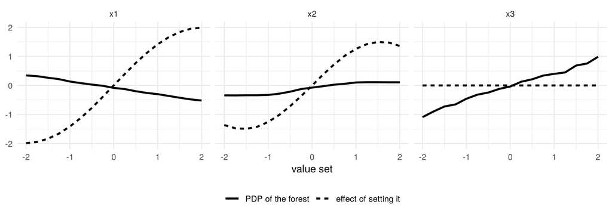

```r
truth <- tibble(t = grid, x1 = sapply(grid, function(t) world_do_x1(1e5, t)),
                x2 = sapply(grid, function(t) world_do_x2(1e5, t)), x3 = 0)
bind_rows(pivot_longer(pd, -t, names_to = "input") |> mutate(curve = "PDP of the forest"),
          pivot_longer(truth, -t, names_to = "input") |> mutate(curve = "effect of setting it")) |>
  ggplot(aes(t, value, linetype = curve)) + geom_line(linewidth = 1) + facet_wrap(~ input) +
  labs(x = "value set", y = NULL, linetype = NULL) + theme(legend.position = "bottom")
```

**TipReveal answer**

Setting $x_1$ from $-1$ to $1$ raises the mean of $y$ by 2.83; setting $x_2$, by 2.52. Setting $x_3$ changes nothing: $y$’s equation does not contain $x_3$, so $\mathbb E[y \mid do(x_3 = t)] = \mathbb E[y]$ for every $t$. The input every tool ranked first has no effect, and the PDP for $x_1$ has the wrong sign. In closed form, $\mathbb E[y \mid do(x_1 = t)] = \frac12 t + \frac32 e^{-0.32}\sin t$, since $\mathbb E\sin(t + \varepsilon_2) = e^{-0.8^2/2}\sin t$ for $\varepsilon_2 \sim N(0, 0.8^2)$; and $\mathbb E[y \mid do(x_2 = t)] = \frac32\sin t$, since $\mathbb E x_1 = 0$.

The tools miss because each describes the forest, and the forest is right about prediction. Given $x_3 = y + x_1 + \varepsilon_3$, a larger $x_1$ with $x_3$ held fixed means a smaller $y$, which is what the PDP for $x_1$ shows. That is a fact about the conditional distribution, not about what setting $x_1$ does.

Common errors: drawing `x1` at random in `world_do_x1`, which is the observational mean again; leaving out the line for `x2`, so that setting $x_1$ does not reach $y$ through $x_2$.

**Question 10.** Fit two more models: a forest on $x_1$ and $x_2$ only (the forest `fit_no_x3` from question 6), and a smooth of $x_1$ alone, `gam(y ~ s(x1), data = world)`. Compute each model’s PDP for $x_1$ and its fresh MSE. Which PDP matches the effect of setting $x_1$, and which model predicts best? To read the effect of $x_2$ from a PDP, which inputs should the model include? Which of the tools in questions 6 and 7 could have told you which model to read?

```r
# fit_x1 <- ____
# rbind(forest_x1_x2 = pdp_curve(fit_no_x3, d_pd, "x1", c(-1, 0, 1)),
#       gam_x1 = ____,
#       effect = truth$x1[truth$t %in% c(-1, 0, 1)])
# c(all_three = base, x1_x2 = ____, x1 = ____)
```

**TipReveal solution**

```r
fit_x1 <- gam(y ~ s(x1), data = world)
q10 <- rbind(forest_x1_x2 = pdp_curve(fit_no_x3, d_pd, "x1", c(-1, 0, 1)),
             gam_x1 = pdp_curve(fit_x1, d_pd, "x1", c(-1, 0, 1)),
             effect = truth$x1[truth$t %in% c(-1, 0, 1)])
colnames(q10) <- c("t = -1", "t = 0", "t = 1")
round(q10, 2)
```

```
             t = -1 t = 0 t = 1
forest_x1_x2  -0.54 -0.03  0.33
gam_x1        -1.35 -0.03  1.39
effect        -1.41  0.00  1.42
```

```r
q10_mse <- c(all_three = base, x1_x2 = mse(world_fresh$y, predict(fit_no_x3, world_fresh)),
             x1 = mse(world_fresh$y, predict(fit_x1, world_fresh)))
round(q10_mse, 3)
```

```
all_three     x1_x2        x1
    0.081     0.281     0.717
```

```r
pdp_x2 <- pdp_curve(fit_no_x3, d_pd, "x2", c(-1, 1))
```

**TipReveal answer**

| Model | PDP for $x_1$ at $-1$, 0, 1 | Fresh MSE |
| --- | --- | --- |
| Forest on $x_1, x_2, x_3$ | 0.13, -0.09, -0.30 | 0.081 |
| Forest on $x_1, x_2$ | -0.54, -0.03, 0.33 | 0.281 |
| Smooth of $x_1$ | -1.35, -0.03, 1.39 | 0.717 |
| Effect of setting $x_1$ | -1.41, 0.00, 1.42 |  |

The smooth of $x_1$ alone matches the effect, and it predicts worst. In this world $x_1$ has no common cause with $y$, so $\mathbb E[y \mid x_1]$ is the effect of setting $x_1$. The forest on $x_1$ and $x_2$ holds $x_2$, a mediator, at each unit’s value, so its PDP shows roughly the direct part of $x_1$’s effect, $\frac12 t$, estimated poorly where the forest is asked about combinations of $x_1$ and $x_2$ that are rare in the data. The forest on all three also holds $x_3$, a consequence of $y$, and its PDP has the wrong sign.

For the effect of $x_2$, the model should include $x_1$, a common cause of $x_2$ and $y$, and leave out $x_3$, a consequence of $y$: the forest on $x_1$ and $x_2$. Its PDP for $x_2$ rises by 2.77 from $-1$ to $1$, against 2.52 for the effect.

None of the tools in questions 6 and 7 could tell you which model to read for which question, and neither could the fresh MSE, which ranks the models the other way. That takes the causal graph: which inputs are common causes, which are mediators and which are consequences of $y$.

Common errors: picking the model with the smallest MSE to answer the causal question; reading the forest on $x_1$ and $x_2$ as giving the total effect of $x_1$.

### Optional, can be done at home: recalibrating a score

Boosted trees with xgboost’s defaults predict diabetes from nine measurements, fitted on the lecture’s training adults ([data note](https://ml4ds.com/data/nhanes.html)).

```r
inputs <- c("Age", "male", "BMI", "Pulse", "BPSysAve", "TotChol", "DirectChol", "Poverty", "active")
fit_xg <- xgboost(x = as.matrix(nh_train[inputs]), y = factor(nh_train$diabetes), nthread = 1)
p_tune <- predict(fit_xg, as.matrix(nh_tune[inputs]))   # predicted probabilities for the tuning adults
logit <- function(p) log(p / (1 - p))
log_loss <- function(y, p) -mean(y * log(p) + (1 - y) * log(1 - p))
```

**Question 11.** Complete `reliability(p, y)`: sort the adults into ten bins of equal size by their score (`ntile()`), and return each bin’s average score and share with diabetes. Apply it to the tuning adults. Where is the score too confident?

```r
# reliability <- function(p, y) tibble(p, y) |>
#   mutate(bin = ____) |>
#   group_by(bin) |>
#   summarise(mean_p = ____, share = ____)
# reliability(p_tune, nh_tune$diabetes)
```

**TipReveal solution**

```r
reliability <- function(p, y) tibble(p, y) |>
  mutate(bin = ntile(p, 10)) |>
  group_by(bin) |>
  summarise(mean_p = mean(p), share = mean(y))
rel_tune <- reliability(p_tune, nh_tune$diabetes)
rel_tune
```

```
# A tibble: 10 x 3
     bin    mean_p   share
   <int>     <dbl>   <dbl>
 1     1 0.0003482 0.01
 2     2 0.001194  0.03
 3     3 0.002875  0.03333
 4     4 0.006850  0.06667
 5     5 0.01473   0.08
 6     6 0.03197   0.1233
 7     7 0.06269   0.1867
 8     8 0.1277    0.2
 9     9 0.2587    0.2467
10    10 0.6068    0.3967
```

**TipReveal answer**

At both ends. In the top bin the average score is 0.61 and the share with diabetes 0.40; in the bottom bins the scores are near 0 while 3% to 7% of the adults have diabetes. The trees push their scores too far toward 0 and 1.

**Question 12.** Recalibrate. On the first 1,500 tuning adults, fit a logistic regression of diabetes on the logit of the score; apply it to the other 1,500. Compare the reliability tables and the log loss on those 1,500, before and after. Is the new score an increasing function of the old one?

```r
# half_a <- 1:1500
# half_b <- 1501:3000
# recal <- glm(____, family = binomial,
#              data = tibble(diabetes = nh_tune$diabetes[half_a], logit_p = ____))
# p_new <- predict(recal, tibble(logit_p = ____), type = "response")
# c(before = log_loss(nh_tune$diabetes[half_b], p_tune[half_b]), after = ____)
```

**TipReveal solution**

```r
half_a <- 1:1500
half_b <- 1501:3000
recal <- glm(diabetes ~ logit_p, family = binomial,
             data = tibble(diabetes = nh_tune$diabetes[half_a], logit_p = logit(p_tune[half_a])))
p_new <- predict(recal, tibble(logit_p = logit(p_tune[half_b])), type = "response")
q12 <- c(before = log_loss(nh_tune$diabetes[half_b], p_tune[half_b]), after = log_loss(nh_tune$diabetes[half_b], p_new))
round(coef(recal), 2)
```

```
(Intercept)     logit_p
      -0.61        0.39
```

```r
round(q12, 3)
```

```
before  after
 0.375  0.329
```

```r
reliability(p_tune[half_b], nh_tune$diabetes[half_b])   # before, on the same 1,500 adults
```

```
# A tibble: 10 x 3
     bin    mean_p   share
   <int>     <dbl>   <dbl>
 1     1 0.0003593 0
 2     2 0.001223  0.02667
 3     3 0.002960  0.02667
 4     4 0.006813  0.06
 5     5 0.01480   0.07333
 6     6 0.03240   0.1133
 7     7 0.06323   0.16
 8     8 0.1292    0.1867
 9     9 0.2658    0.2933
10    10 0.6074    0.38
```

```r
reliability(p_new, nh_tune$diabetes[half_b])            # after
```

```
# A tibble: 10 x 3
     bin  mean_p   share
   <int>   <dbl>   <dbl>
 1     1 0.02331 0
 2     2 0.03816 0.02667
 3     3 0.05294 0.02667
 4     4 0.07204 0.06
 5     5 0.09517 0.07333
 6     6 0.1256  0.1133
 7     7 0.1589  0.16
 8     8 0.2039  0.1867
 9     9 0.2663  0.2933
10    10 0.3999  0.38
```

**TipReveal answer**

The fitted slope on the logit is 0.39, positive, so the new score is an increasing function of the old one: the order of the adults is unchanged, and only the numbers attached to them move. A slope below 1 pulls the scores toward the middle, which is what a score that is too confident at both ends needs. The log loss on the other 1,500 adults falls from 0.375 to 0.329, and on those adults the reliability table moves from a top bin that is too high to one close to the diagonal. The recalibration is fitted on adults not used to fit the trees, and checked on adults not used to fit either.

Common errors: fitting the recalibration on the training adults, whose scores look better than they are; scoring it on the 1,500 adults it was fitted on, which makes the “after” number look better than it is.

## References

- Chouldechova, A. (2017). Fair prediction with disparate impact: a study of bias in recidivism prediction instruments. *Big Data* 5(2), 153–163. [doi:10.1089/big.2016.0047](https://doi.org/10.1089/big.2016.0047)
- Kleinberg, J., Mullainathan, S. and Raghavan, M. (2017). Inherent trade-offs in the fair determination of risk scores. *8th Innovations in Theoretical Computer Science Conference (ITCS 2017)*, LIPIcs 67, 43:1–43:23. [doi:10.4230/LIPIcs.ITCS.2017.43](https://doi.org/10.4230/LIPIcs.ITCS.2017.43)
- Lei, J., G’Sell, M., Rinaldo, A., Tibshirani, R. J. and Wasserman, L. (2018). Distribution-free predictive inference for regression. *Journal of the American Statistical Association* 113(523), 1094–1111. [doi:10.1080/01621459.2017.1307116](https://doi.org/10.1080/01621459.2017.1307116)
- The NHANES adults: [data note](https://ml4ds.com/data/nhanes.html).